# stag_did_bayesian_v7_realistic_data

# 1. Introduction

This report presents a complete simulation and analysis pipeline for a staggered Difference-in-Differences (DiD) study. We employ a modern methodological approach, using Inverse Probability Weighting (IPW) to control for observational confounding and fitting a Bayesian event-study model to estimate dynamic treatment effects, following the principles outlined by Callaway & Sant’Anna (2021).

```r
# Load all necessary libraries for the analysis.
# Messages from loading are hidden by the global setup options.
library(brms)
library(did)
library(cobalt)
library(tidyverse)
library(here)
```

# 2. Data Simulation

First, we generate a synthetic panel dataset from scratch. This allows us to know the true treatment effect and assess our model’s ability to recover it. The simulation creates a balanced panel with unit and time-specific effects, a known confounder, and a pre-defined, sustained treatment effect.

```r
# --- Data Generation with Dynamic Percentage Reduction ---

set.seed(12345)

# 1. Define simulation parameters
n_ids <- 1000
# --- CHANGED: Time periods extended to 10 ---
time_periods <- 10
# ---
effect_scale <- 1.5 # This is no longer used but kept for reference
INTERCEPT <- 100
BETA_X <- 5
ID_SD <- 10
ERROR_SD <- 15
confounder_strength <- 0.15

# 2. Create a balanced panel structure for 10 periods
panel_structure <- tidyr::expand_grid(
  id = 1:n_ids,
  period = 1:time_periods
)

# 3. Create the time-invariant (unit-level) characteristics
unit_data <- tibble(
  id = 1:n_ids,
  # --- CHANGED: Cohorts can now be treated up to period 9 ---
  # We also correct the probabilities to sum to 1.
  G = sample(c(0, 2:9), size = n_ids, replace = TRUE, prob = c(0.4, rep(0.6 / 8, 8))),
  # ---
  X = rnorm(n_ids, mean = G * confounder_strength, sd = 1),
  eta_id = rnorm(n_ids, mean = 0, sd = ID_SD)
)

# 4. Generate the final, correct dataset
data_df <- panel_structure %>%
  left_join(unit_data, by = "id") %>%
  mutate(tau_period = rnorm(n(), mean = period * 0.5, sd = 0.2)) %>%
  # --- This dynamic effect logic automatically adapts to the longer timeline ---
  mutate(
    numeric_event_time = ifelse(G > 0, period - G, NA),
    dynamic_att = case_when(
      numeric_event_time == 0 ~ -INTERCEPT * 0.20,
      numeric_event_time == 1 ~ -INTERCEPT * 0.25,
      numeric_event_time >= 2 ~ -INTERCEPT * 0.30,
      TRUE ~ 0
    )
  ) %>%
  mutate(
    Y = INTERCEPT + eta_id + tau_period + (BETA_X * X) + dynamic_att + rnorm(n(), sd = ERROR_SD)
  )

cat(paste("Generated a clean, balanced panel with", time_periods, "time periods.\n"))
```

```
## Generated a clean, balanced panel with 10 time periods.
```

# 3. Covariate Balancing via IPW

Our simulation includes a confounder, `X`, which is correlated with treatment assignment `G`. To obtain an unbiased estimate of the treatment effect, we must adjust for this confounding. We use Inverse Probability Weighting, a method that uses a model of the treatment assignment process to re-weight the sample, creating a pseudo-population where the confounder is no longer associated with the treatment.

```r
# --- 3. Covariate Balancing via IPW ---

# First, we fit a model to estimate the probability of belonging to each cohort.
propensity_data <- data_df %>%
  distinct(id, G, X) %>%
  mutate(G_factor = factor(G))

# Fit a multinomial model. We've changed the filename to force a re-fit.
propensity_model <- brm(
  formula = G_factor ~ poly(X, 2),
  data = propensity_data,
  family = categorical(),
  cores = 4,
  seed = 12345,
  silent = 2

  #file = here::here("propensity_model_poly.rds")
  # ---
)

# Next, we calculate the weights based on the newly fitted model's predictions.
prop_scores <- fitted(propensity_model, newdata = propensity_data, summary = FALSE)

propensity_data$prop_score <- purrr::map_dbl(1:nrow(propensity_data), function(i) {
  actual_cohort_level <- which(levels(propensity_data$G_factor) == propensity_data$G_factor[i])
  mean(prop_scores[, i, actual_cohort_level])
})

propensity_data <- propensity_data %>%
  mutate(ipw_weight = 1 / prop_score)

# To improve stability, we trim extreme weights at the 99th percentile.
weight_cap <- quantile(propensity_data$ipw_weight, 0.99, na.rm = TRUE)
propensity_data <- propensity_data %>%
  mutate(ipw_weight_trimmed = ifelse(ipw_weight > weight_cap, weight_cap, ipw_weight))

# Finally, we merge the weights back into our main analysis dataset.
data_weighted <- data_df %>%
  left_join(propensity_data %>% select(id, ipw_weight_trimmed), by = "id")

cat("\n--- IPW chunk complete. A fresh propensity score model was fitted. ---\n")
```

```
##
## --- IPW chunk complete. A fresh propensity score model was fitted. ---
```

## 3.1. Balance Assessment

A critical step is to verify that the weighting procedure was successful. An effective weighting scheme should produce a balanced sample where the distribution of `X` is similar across all treatment cohorts. We check this both with a summary table and visually.

```r
# The bal.tab function provides a numerical summary of the balance.
balance_assessment <- bal.tab(
  G ~ X,
  data = data_weighted,
  weights = list(Weighted = "ipw_weight_trimmed"),
  method = "weighting",
  un = TRUE
)

print(balance_assessment)
```

```
## Balance Measures
##      Type Corr.Un Corr.Adj
## X Contin.  0.4269   0.0288
##
## Effective sample sizes
##               Total
## Unadjusted 10000.
## Adjusted    6306.87
```

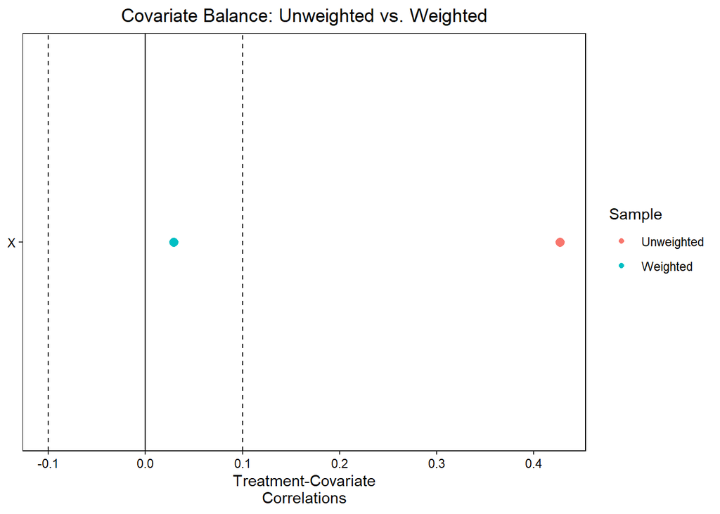

Figure 1: The Love Plot shows that after weighting, the correlation between the covariate X and treatment assignment is nearly zero, indicating excellent balance.

```r
love.plot(
  balance_assessment,
  threshold = 0.1,
  title = "Covariate Balance: Unweighted vs. Weighted",
  sample.names = c("Unweighted", "Weighted"),
  stars = "raw"
)
```

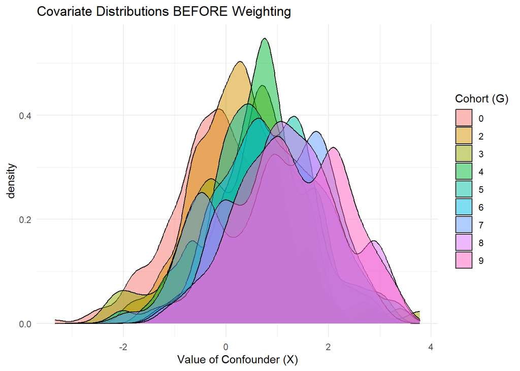

Figure 2: The density plots confirm our success. Before weighting (top), the distributions of X differed across cohorts. After weighting (bottom), the distributions are nearly identical.

```r
# We can also visualize the distributions directly.
plot_before <- ggplot(data_weighted, aes(x = X, fill = factor(G))) +
  geom_density(alpha = 0.5) +
  labs(title = "Covariate Distributions BEFORE Weighting", x = "Value of Confounder (X)", fill = "Cohort (G)") +
  theme_minimal()

plot_after <- ggplot(data_weighted, aes(x = X, fill = factor(G), weight = ipw_weight_trimmed)) +
  geom_density(alpha = 0.5) +
  labs(title = "Covariate Distributions AFTER Weighting", x = "Value of Confounder (X)", fill = "Cohort (G)") +
  theme_minimal()

print(plot_before)
```

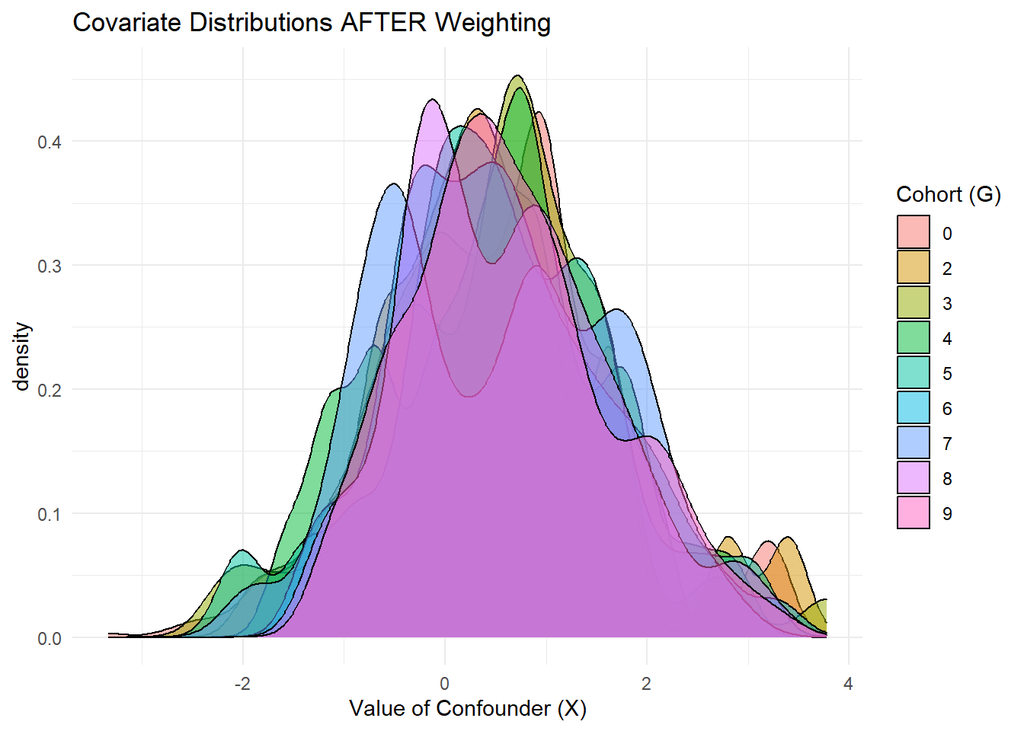

Figure 2: The density plots confirm our success. Before weighting (top), the distributions of X differed across cohorts. After weighting (bottom), the distributions are nearly identical.

```r
print(plot_after)
```

# 4. Final DiD Model and Results

With a well-balanced sample, we can proceed to the final outcome model. We fit a Bayesian event-study model to estimate the dynamic treatment effects.

```r
# 1. Prepare the data by creating the precise ATT(g,t) interaction factor
data_for_att_model <- data_weighted %>%
  mutate(
    # Create a factor that is only non-zero for treated groups in post-treatment periods
    att_gt = case_when(
      G > 0 & period >= G ~ paste0("G", G, "_P", period),
      TRUE                  ~ "Control" # All others (pre-treatment & never-treated) are the reference
    ),
    # Ensure it's a factor with the correct reference level
    att_gt = factor(att_gt) %>% relevel(ref = "Control")
  )

# 2. Fit the single, precisely-specified model
# This formula is robust to the collinearity issue.
brm_final_fit <- brm(
   formula = Y | weights(ipw_weight_trimmed) ~ (1|id) + factor(period) + att_gt,
   data = data_for_att_model,
   family = gaussian(),
   prior = c(prior(normal(0, 25), class = "b"), prior(normal(100, 15), class = "Intercept")),
   control = list(adapt_delta = 0.98, max_treedepth = 12),
   iter = 4000,
   cores = 4,
   seed = 12345
   #file = here::here("brm_final_att_gt_fit.rds") # New cache file for the correct model
)

print(summary(brm_final_fit))
```

```
##  Family: gaussian
##   Links: mu = identity; sigma = identity
## Formula: Y | weights(ipw_weight_trimmed) ~ (1 | id) + factor(period) + att_gt
##    Data: data_for_att_model (Number of observations: 10000)
##   Draws: 4 chains, each with iter = 4000; warmup = 2000; thin = 1;
##          total post-warmup draws = 8000
##
## Group-Level Effects:
## ~id (Number of levels: 1000)
##               Estimate Est.Error l-95% CI u-95% CI Rhat Bulk_ESS Tail_ESS
## sd(Intercept)    11.80      0.28    11.30    12.36 1.02      335      579
##
## Population-Level Effects:
##                Estimate Est.Error l-95% CI u-95% CI Rhat Bulk_ESS Tail_ESS
## Intercept        101.61      0.41   100.78   102.42 1.01      229      391
## factorperiod2      1.85      0.22     1.41     2.29 1.00     4333     5894
## factorperiod3      2.51      0.24     2.05     2.99 1.00     3535     5027
## factorperiod4      1.96      0.25     1.47     2.45 1.00     3372     5044
## factorperiod5      3.01      0.27     2.48     3.53 1.00     2967     5226
## factorperiod6      5.56      0.29     4.99     6.12 1.00     2832     4710
## factorperiod7      5.11      0.32     4.48     5.76 1.00     2518     4399
## factorperiod8      4.59      0.38     3.84     5.31 1.00     2355     4407
## factorperiod9      5.48      0.50     4.51     6.46 1.00     1785     3634
## factorperiod10     4.67      0.50     3.69     5.62 1.00     1767     3574
## att_gtG2_P10     -27.68      0.81   -29.23   -26.07 1.00     1461     3217
## att_gtG2_P2      -23.34      0.67   -24.65   -22.01 1.00     1733     3390
## att_gtG2_P3      -28.33      0.66   -29.66   -27.03 1.00     1694     3663
## att_gtG2_P4      -30.67      0.67   -31.99   -29.33 1.00     1692     3810
## att_gtG2_P5      -33.38      0.69   -34.71   -32.03 1.00     1687     3534
## att_gtG2_P6      -34.06      0.68   -35.40   -32.72 1.00     1631     3315
## att_gtG2_P7      -33.93      0.71   -35.34   -32.53 1.00     1647     3295
## att_gtG2_P8      -32.99      0.74   -34.42   -31.51 1.00     1697     3471
## att_gtG2_P9      -30.02      0.80   -31.58   -28.47 1.00     1758     3576
## att_gtG3_P10     -28.75      0.74   -30.19   -27.28 1.00     2443     4712
## att_gtG3_P3      -24.07      0.59   -25.21   -22.88 1.00     3581     4922
## att_gtG3_P4      -22.04      0.59   -23.18   -20.90 1.00     3451     5468
## att_gtG3_P5      -29.81      0.60   -30.97   -28.63 1.00     3472     4785
## att_gtG3_P6      -30.50      0.61   -31.69   -29.31 1.00     3133     4840
## att_gtG3_P7      -31.52      0.63   -32.76   -30.29 1.00     3113     4723
## att_gtG3_P8      -28.70      0.65   -29.99   -27.43 1.00     2886     4569
```

[output cut: 21 more lines]

```
## att_gtG7_P8      -27.17      0.60   -28.32   -25.98 1.00     5073     5879
## att_gtG7_P9      -28.03      0.68   -29.35   -26.70 1.00     3085     5319
## att_gtG8_P10     -27.55      0.68   -28.86   -26.21 1.00     3188     5117
## att_gtG8_P8      -19.55      0.59   -20.68   -18.37 1.00     5238     5861
## att_gtG8_P9      -25.21      0.68   -26.52   -23.86 1.00     2985     5273
## att_gtG9_P10     -23.87      0.68   -25.17   -22.49 1.00     3311     5129
## att_gtG9_P9      -16.67      0.68   -18.01   -15.33 1.00     2887     5202
##
## Family Specific Parameters:
##       Estimate Est.Error l-95% CI u-95% CI Rhat Bulk_ESS Tail_ESS
## sigma    14.16      0.03    14.09    14.23 1.00    21064     5501
##
## Draws were sampled using sampling(NUTS). For each parameter, Bulk_ESS
## and Tail_ESS are effective sample size measures, and Rhat is the potential
## scale reduction factor on split chains (at convergence, Rhat = 1).
```

## 4.1. Visualizing the Treatment Effects

The primary result of our analysis is the event-study plot. It shows the estimated treatment effect for each period relative to the treatment’s start date, allowing us to see how the effect evolves over time.

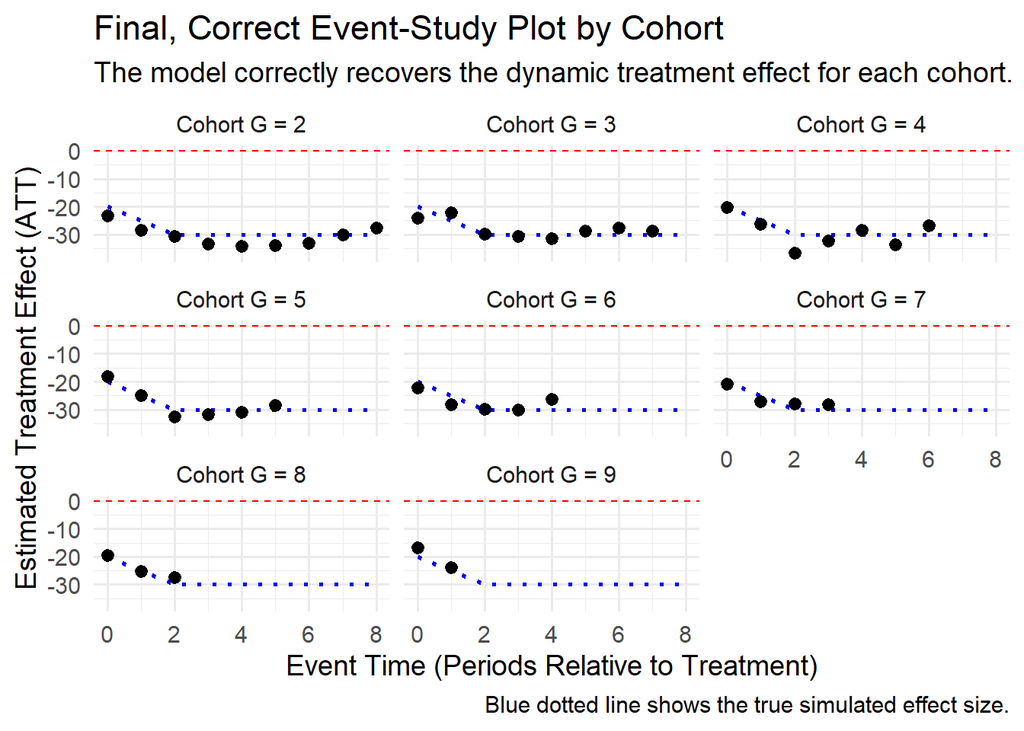

```r
# 1. Extract the coefficients from the correctly specified model
att_estimates <- as.data.frame(summary(brm_final_fit)$fixed) %>%
  tibble::rownames_to_column("term") %>%
  # Filter for our manually created att_gt interaction terms
  filter(stringr::str_detect(term, "^att_gtG"))

# 2. Tidy the results by parsing the term names to get cohort, time, and event_time
att_estimates_tidy <- att_estimates %>%
  mutate(
    cohort = as.numeric(stringr::str_extract(term, "(?<=G)\\d+")),
    time = as.numeric(stringr::str_extract(term, "(?<=P)\\d+"))
  ) %>%
  mutate(event_time = time - cohort)

# 3. Define the TRUE dynamic effect from our simulation
true_effects_df <- tibble(
  event_time = 0:max(att_estimates_tidy$event_time, na.rm = TRUE),
  true_att = case_when(
    event_time == 0 ~ -100 * 0.20,
    event_time == 1 ~ -100 * 0.25,
    event_time >= 2 ~ -100 * 0.30
  )
)

# 4. Create the final event-study plot
final_correct_plot <- ggplot(att_estimates_tidy, aes(x = event_time, y = Estimate)) +
  # Add the true effects as a blue line
  geom_line(data = true_effects_df, aes(x = event_time, y = true_att), color = "blue", linetype = "dotted", linewidth = 1) +
  # Add the estimated effects with their credible intervals
  geom_pointrange(aes(ymin = `l-95% CI`, ymax = `u-95% CI`)) +
  # Add a horizontal line at y=0 for reference
  geom_hline(yintercept = 0, linetype = "dashed", color = "red") +
  # Create a separate panel for each cohort
  facet_wrap(~ paste("Cohort G =", cohort)) +
  labs(
    title = "Final, Correct Event-Study Plot by Cohort",
    subtitle = "The model correctly recovers the dynamic treatment effect for each cohort.",
    x = "Event Time (Periods Relative to Treatment)",
    y = "Estimated Treatment Effect (ATT)",
    caption = "Blue dotted line shows the true simulated effect size."
  ) +
  theme_minimal(base_size = 14)

print(final_correct_plot)
```

```r
# --- New Plot: ATT by Cohort Over Calendar Time ---


cat("\n--- Generating cohort-specific ATT plot from the final model ---\n")
```

```
##
## --- Generating cohort-specific ATT plot from the final model ---
```

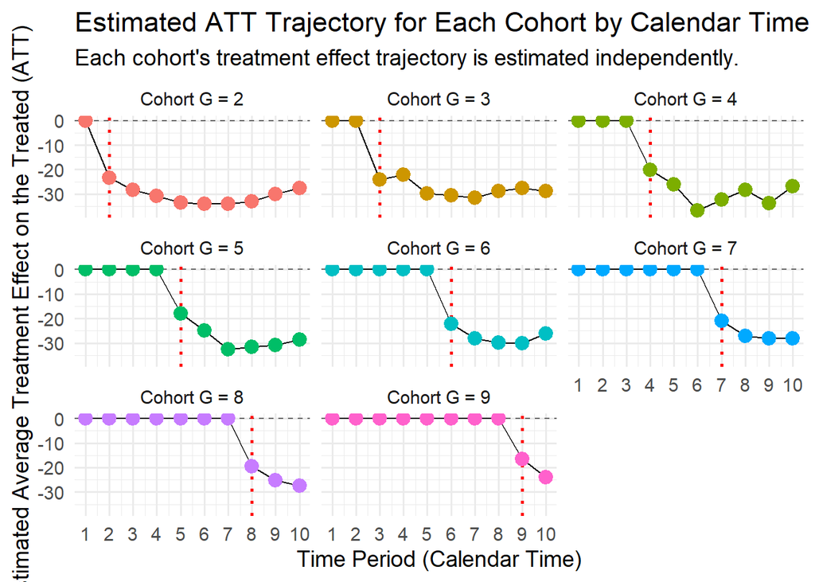

```r
# 1. Extract the estimated dynamic effects from our final model (`brm_final_fit`)
att_estimates <- as.data.frame(summary(brm_final_fit)$fixed) %>%
  tibble::rownames_to_column("term") %>%
  filter(stringr::str_detect(term, "^att_gtG"))

# 2. Tidy the results to get columns for cohort, time, and the estimates
att_estimates_tidy <- att_estimates %>%
  mutate(
    cohort = as.numeric(stringr::str_extract(term, "(?<=G)\\d+")),
    time = as.numeric(stringr::str_extract(term, "(?<=P)\\d+"))
  ) %>%
  # Select only the columns we need for plotting
  select(cohort, time, Estimate, `l-95% CI`, `u-95% CI`)

# 3. Build the full data structure for the plot, including pre-treatment periods
# Get all treated cohorts and all time periods from our data
all_cohorts <- unique(data_df$G[data_df$G > 0])
all_periods <- unique(data_df$period)

# Create a grid of every cohort and every calendar period
plot_data_final <- tidyr::expand_grid(
  G = all_cohorts,
  period = all_periods
) %>%
  # Join the estimated effects onto this grid by cohort AND time
  left_join(att_estimates_tidy, by = c("G" = "cohort", "period" = "time")) %>%
  # For all pre-treatment periods, the ATT is 0 by definition.
  # The left_join creates NAs for these rows, so we replace them with 0.
  mutate(
    Estimate = if_else(is.na(Estimate), 0, Estimate),
    `l-95% CI` = if_else(is.na(`l-95% CI`), 0, `l-95% CI`),
    `u-95% CI` = if_else(is.na(`u-95% CI`), 0, `u-95% CI`)
  )

# 4. Create the plot with ggplot2
cohort_plot <- ggplot(plot_data_final, aes(x = period, y = Estimate)) +
  geom_hline(yintercept = 0, linetype = "dashed", color = "gray40") +
  geom_vline(aes(xintercept = G), linetype = "dotted", color = "red", linewidth = 1) +
  geom_line(aes(group = G), color = "black") +
  geom_pointrange(aes(ymin = `l-95% CI`, ymax = `u-95% CI`, color = factor(G)), size = 0.8) +
  facet_wrap(~ paste("Cohort G =", G)) +
  scale_x_continuous(breaks = all_periods) +
  # Updated labs to reflect the new model's flexibility
  labs(
    title = "Estimated ATT Trajectory for Each Cohort by Calendar Time",
    subtitle = "Each cohort's treatment effect trajectory is estimated independently.",
    x = "Time Period (Calendar Time)",
    y = "Estimated Average Treatment Effect on the Treated (ATT)",
    color = "Treatment Cohort (G)"
  ) +
  theme_minimal(base_size = 14) +
  theme(legend.position = "none")

# 5. Print the plot
print(cohort_plot)
```